# Wellbeing and lifestyle data

### 3.7 Next steps

Here there are some ideas to improve our model done up to now:

- A better perform of that linear model can be achieved by adding some features. Some ideas are the level of noise people are exposed to, how many hours are spent in nature or how many negative people do respondents have in their social circle (according to their criteria, which is what matters). On the other hand, one advanced model can be done from a more technical study, where measures of corporal indicators related to stress from medical analysis could be used along with measures of noise in decibels and other measurable features.
- We could perform clusttering or classification algorithms, which might perform better than the linear model as we are dealing with discrete categories within intervals instead of continuous variables. Some other data can be gathered for this model. For example, new features as the *living area* (big city/town/village) might have impact on stress. It is said that people in cities are in general more stressed, and in fact noise of modern life is a well known source of stress. We could also add information related to the type job (physical/sedentary) or the workday hours, and related to the social network, it would be insightful to get information about *how* is the people we are surrounded by, and not only the amount of people as this dataset takes into account. We are very influenced by our social circle, and prove up to what point this is true by dividing people in clustters or performing a classification algorithm for prediction, and see for example whether stressed or successful people are usually surounded by other stressed or successful people respectively.

## 6. Statistical Hypothesis Testing for dependencies and correlations between variables

I'll perform some tests for some pairs for variables to prove whether it is a dependency and, going one step ahead, whether there is a correlation between them.

### 𝜒2 test to check independency:

I'll calculate the statistic: $\chi^2 =\large \sum_{i} \frac{(O_{i} - E_{i})^2}{E_{i}}$, where:  
$O_{i}$ is each of the observed (real) values  
$E_{i}$ is each of the expected values, so the value we would expect according to the female/male proportion if no gender dependency took place.

I'll create a function that shows the crosstab counts of 2 variables, both observed and expected (from the proportion of each category within the variable it belongs to), and calculates the $\chi^2$ statistic:

```python
def independence_test(variable1, variable2):

    '''
    Return: DataFrame comparing observed vs expected data, chi2, chi2_matrix (addends, contributions to the value of chi2)

    Example:

    >> df, chi2 = correlation_test('feature1', 'feature2')
    '''

    # variable1 in Rows
    # variable2 in Columns

    # Proportions
    proportions = (data[variable2].value_counts()/data[variable2].count()).sort_index()

    # Expected values
    value_counts_var1 = (data[variable1].value_counts()).sort_index()
    expected_df = pd.DataFrame()
    for index,value in zip(proportions.index, proportions.values):
        expected_df[index] = value_counts_var1*value

    # Observed values
    observed_df = pd.crosstab(data[variable1], data[variable2])
    observed_df.index.name = None
    observed_df.columns.name = None

    # Dataframe Observed vs Expected values
    reality = ['Observed','Expected']
    df_concat = pd.concat([observed_df, expected_df], axis=1, keys=reality)
    df_concat = df_concat.sort_index(axis=1, level=1)
    df_concat.columns = df_concat.columns.map(lambda x: x[::-1])
    df_concat = df_concat.sort_index(axis=0)
    print('Index: Values of {} \nColumns: Values of {}'.format(variable1, variable2))
    display(df_concat)

    # Chi2
    print("-"*100)
    print("\nCalculation of chi2:")
    print("\nAddends (contributions to the values of chi2):")
    chi2_matrix = (((expected_df - observed_df)**2)/expected_df).sort_index(axis=1)
    chi2_matrix.index.name = variable1
    chi2_matrix.columns.name = variable2
    display(chi2_matrix)
    chi2 = chi2_matrix.sum(axis=1).sum(axis=0)
    print("chi2:", chi2)

    return df_concat, chi2, chi2_matrix
```

### t-test to check correlation

Let's perform a signiicance test to prove whether there is a correlations significantly different from 0. We'll use $t = \frac{r\sqrt{n-2}}{\sqrt{1-r^2}}$. Explanations about this expression and the significance test for correlations are commented in "observations" section.

```python
def correlation_test(variable1, variable2):

    '''
    Return: t statistic

    '''

    r = data.corr()[variable1][variable2]
    n = data.shape[0]
    std_r = np.sqrt((1-r**2)/(n-2))
    print("Correlation coefficient r: ", r)
    print("Standard error of correlation coefficient: ", std_r)

    #t statistic
    t_statistic = (r*np.sqrt(n-2))/np.sqrt(1-r**2)
    print("\nt statistic: ", t_statistic)

    return t_statistic
```

### $H_{0}$: Stress levels are independent of gender: woman are as stressed as men

$H_{1}$: Stress levels does depend on gender

**1. $\chi^2$ test to check independency:**

I'll perform a $\chi^2$ test. There are $n_{1} = 6$ stress levels and $n_{2} = 2$ posible values for gender, so we have $(n_{1} - 1)*(n_{2} - 1) = 5$ degrees of freedom. The $\chi^2$ values for 5 degrees of freedom are:

$\chi^2_{0.01, 5} = 15.087$ for 99% of confidence level  
$\chi^2_{0.005, 5} = 16.75$ for 99.5% of confidence level  
$\chi^2_{0.001, 5} = 20.515$ for 99.9% of confidence level

```python
print(gender_translator, "\n")
df_concat_stress_gender, chi2_stress_gender, chi2_matrix_stress_gender = independence_test('daily_stress', 'gender')
```

```
{'Female': 0, 'Male': 1}

Index: Values of daily_stress
Columns: Values of gender
```

|  | 0 Expected | 0 Observed | 1 Expected | 1 Observed |
| --- | --- | --- | --- | --- |
| 0 | 339.887730 | 243 | 222.112270 | 319 |
| 1 | 1207.750529 | 1006 | 789.249471 | 991 |
| 2 | 1631.703018 | 1592 | 1066.296982 | 1106 |
| 3 | 2137.905919 | 2270 | 1397.094081 | 1265 |
| 4 | 1403.095257 | 1448 | 916.904743 | 872 |
| 5 | 993.657546 | 1155 | 649.342454 | 488 |

```
----------------------------------------------------------------------------------------------------

Calculation of chi2:

Addends (contributions to the values of chi2):
```

| gender daily_stress | 0 | 1 |
| --- | --- | --- |
| 0 | 27.618627 | 42.263457 |
| 1 | 33.701725 | 51.572130 |
| 2 | 0.966064 | 1.478321 |
| 3 | 8.161653 | 12.489385 |
| 4 | 1.437134 | 2.199177 |
| 5 | 26.197544 | 40.088843 |

```
chi2: 248.17405935784157
```

$\chi^2$ for 5 grades of freedom and a significance level of 0.001: $\chi^2_{5,0.001} = 20,5147$. We obtained $248.174$, so we can reject the null hypothesis: "*stress_level* is independent of the gender", with (at least) a 99.9% of confidence level.

**We can accept the alternative hypothesis "stress level depends on gender"**. This doesn't necessarily imply correlation, altough we can appreciate that it does exists. We see the differences between women and men. For low stress levels (0 and 1) there are less women ('Real' values) than expected and more men than expected from the male/female proportion, while for high stress levels (5) there are more women and less men than expected. We see by eye that women suffer more stress than men, generally speaking. But we have to perform a significance test for the correlation, which we'll perform later below, to ensure with numbers it really exists.

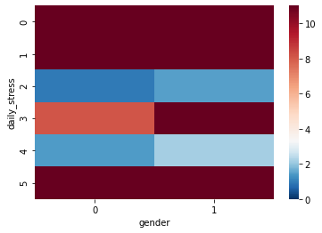

```python
from matplotlib import colors
norm=colors.TwoSlopeNorm(vmin=0, vcenter=6.63/2, vmax=11)
sns.heatmap(chi2_matrix_stress_gender, norm=norm, cmap='RdBu_r');
```

The t-student value is $t_{1, 0.01} = 6.63$ for a 0.01 of significance level, so at the heatmap, reds are the ones contributing to the row sum to be 6.63 and thus contributing to that particular level of stress to be significantly dependent of gender.

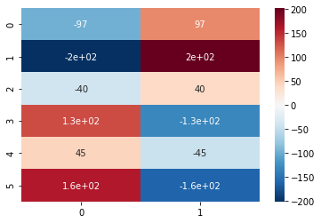

```python
df_diff = pd.DataFrame()
for col in df_concat_stress_gender.columns.levels[0]:
    df_diff[col] = (df_concat_stress_gender[(col,'Observed')] - df_concat_stress_gender[(col,'Expected')])

norm=colors.TwoSlopeNorm(vmin=df_diff.min().min(), vcenter=0, vmax=df_diff.max().max())
sns.heatmap(df_diff, norm=norm, cmap='RdBu_r', annot=True);
```

We clearly see a correlation, where there are more observed cases for the pairs of categories men (1) - low stress (0,1,2), and for the pairs women (0) - high stress (3,4,5). From the previous heatmap it is appreciable where these differences are significant, and later below, we'll perform a t-test to confirm the significance of the correlation

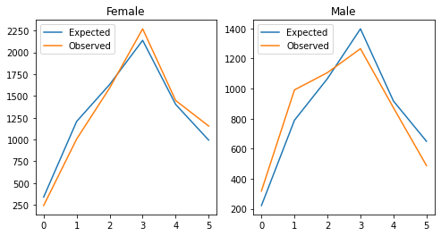

```python
# Plots

plt.figure(figsize=(8,4))

plt.subplot(1,2,1)
plt.plot(df_concat_stress_gender[0])
plt.legend(df_concat_stress_gender[0].columns);
plt.title('Female');

plt.subplot(1,2,2)
plt.plot(df_concat_stress_gender[1])
plt.legend(df_concat_stress_gender[1].columns);
plt.title('Male');
```

**2. t-test to check correlation**

```python
t_statistic = correlation_test('daily_stress', 'gender')

# p-value for n-2 degrees of freedom
from scipy.stats import t
p_value = t.cdf(t_statistic, n-2)*2 #2 tails into account, to obtain P>|t|
print(p_value)
```

```
Correlation coefficient r:  -0.128676852685506
Standar error of correlation coefficient:  0.00878149089059826

t statistic:  -14.653189793007869
3.1680727107627955e-48
```

Residuals should be normally distributed to be strict. However, dependency is ensured by the $\chi^2$ test, and giving a look to data, it is noticeable that this dependency follows a definited direction. Although this t-test is not definitive, things point to the hypothesis **women suffer more stress than men**, and in fact, there are other studies about this reaching our same conclusions.

### $𝐻_0$ : Stress levels are independent of sufficient income

**1. $\chi^2$ test to check independency**

```python
variable1, variable2 = 'daily_stress', 'sufficient_income'
df_concat_stress_income, chi2_stress_income, chi2_matrix_stress_income = independence_test(variable1, variable2)
```

```
Index: Values of daily_stress
Columns: Values of sufficient_income
```

|  | 1 Expected | 1 Observed | 2 Expected | 2 Observed |
| --- | --- | --- | --- | --- |
| 0 | 152.760016 | 111 | 409.239984 | 451 |
| 1 | 542.814504 | 381 | 1454.185496 | 1616 |
| 2 | 733.356801 | 614 | 1964.643199 | 2084 |
| 3 | 960.865935 | 957 | 2574.134065 | 2578 |
| 4 | 630.610741 | 724 | 1689.389259 | 1596 |
| 5 | 446.592003 | 680 | 1196.407997 | 963 |

```
----------------------------------------------------------------------------------------------------

Calculation of chi2:

Addends (contributions to the values of chi2):
```

| sufficient_income daily_stress | 1 | 2 |
| --- | --- | --- |
| 0 | 11.415938 | 4.261311 |
| 1 | 48.237351 | 18.005910 |
| 2 | 19.425805 | 7.251213 |
| 3 | 0.015554 | 0.005806 |
| 4 | 13.830329 | 5.162548 |
| 5 | 121.988958 | 45.535715 |

```
chi2: 295.1364376469751
```

```python
chi2_matrix_stress_income
```

| sufficient_income daily_stress | 1 | 2 |
| --- | --- | --- |
| 0 | 11.415938 | 4.261311 |
| 1 | 48.237351 | 18.005910 |
| 2 | 19.425805 | 7.251213 |
| 3 | 0.015554 | 0.005806 |
| 4 | 13.830329 | 5.162548 |
| 5 | 121.988958 | 45.535715 |

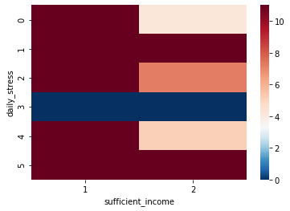

```python
norm=colors.TwoSlopeNorm(vmin=0, vcenter=6.63/2, vmax=11)
sns.heatmap(chi2_matrix_stress_income, norm=norm, cmap='RdBu_r');
```

There are special divergences between expected and observed for a level stress of 5, and also for 1. Similar as the previous case of stress vs gender, the t-student value is 𝑡1,0.01=6.63 for a 0.01 of significance level, so at the heatmap, reds are the ones contributing to the row sum to be 6.63 and thus contributing to that particular level of stress to be significantly dependent of income

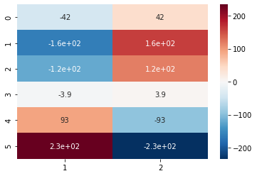

```python
df_diff = pd.DataFrame()
for col in df_concat_stress_income.columns.levels[0]:
    df_diff[col] = (df_concat_stress_income[(col,'Observed')] - df_concat_stress_income[(col,'Expected')])

norm=colors.TwoSlopeNorm(vmin=df_diff.min().min(), vcenter=0, vmax=df_diff.max().max())
sns.heatmap(df_diff, norm=norm, cmap='RdBu_r', annot=True);
```

Once again, we appreciate a negative correlation between these two variables. Let's confirm this correlation is significant:

**2. t-test to check correlation**

```python
t_statistic = correlation_test(variable1, variable2)
p_value = t.cdf(t_statistic, n-2)*2
print("\np-value: ", p_value)
```

```
Correlation coefficient r:  -0.14487168163684583
Standar error of correlation coefficient:  0.008761689756615417

t statistic:  -16.534673751425867

p-value:  8.849120787406811e-61
```

Again, residuals should be normally distributed to be strict. However, dependency is ensured by the 𝜒2 test, and giving a look to data, it is noticeable that this dependency follows a definited direction. Although this t-test is not definitive, things point to the alternative hypothesis: *stress* and *sufficient income* are negatively correlated: the less sufficient income, the more stress. Other studies also support this hypothesis, talking about the so-called "financial stress".

### $𝐻_0$ : Stress levels are independent of daily shouting

**1. $\chi^2$ test to check independency**

```python
variable1, variable2 = 'daily_shouting', 'daily_stress'
output = independence_test(variable1, variable2)
chi2_matrix_stress_shouting = output[2]
df_concat_stress_shouting = output[0]
```

```
Index: Values of daily_shouting
Columns: Values of daily_stress
```

|  | 0 Expected | 0 Observed | 1 Expected | 1 Observed | 2 Expected | 2 Observed | 3 Expected | 3 Observed | 4 Expected | 4 Observed | 5 Expected | 5 Observed |
| --- | --- | --- | --- | --- | --- | --- | --- | --- | --- | --- | --- | --- |
| 0 | 87.241082 | 244 | 310.000784 | 460 | 418.819287 | 436 | 548.749510 | 416 | 360.141121 | 264 | 255.048216 | 160 |
| 1 | 132.668130 | 142 | 471.420384 | 673 | 636.901450 | 699 | 834.487260 | 806 | 547.669149 | 434 | 387.853626 | 257 |
| 2 | 93.894316 | 82 | 333.642258 | 379 | 450.759545 | 538 | 590.598589 | 596 | 387.606429 | 354 | 274.498863 | 182 |
| 3 | 71.379067 | 34 | 253.637005 | 214 | 342.670325 | 370 | 448.976872 | 495 | 294.660917 | 328 | 208.675813 | 179 |
| 4 | 43.840847 | 12 | 155.783222 | 81 | 210.467268 | 210 | 275.760486 | 387 | 180.980008 | 181 | 128.168169 | 124 |
| 5 | 44.413642 | 20 | 157.818581 | 95 | 213.217091 | 192 | 279.363387 | 274 | 183.344571 | 221 | 129.842728 | 206 |
| 6 | 18.285378 | 5 | 64.974912 | 28 | 87.782830 | 68 | 115.015680 | 131 | 75.484124 | 115 | 53.457076 | 68 |
| 7 | 24.013328 | 4 | 85.328499 | 24 | 115.281066 | 77 | 151.044688 | 171 | 99.129753 | 157 | 70.202666 | 112 |
| 8 | 13.086162 | 2 | 46.500118 | 14 | 62.822893 | 27 | 82.312426 | 105 | 54.021168 | 76 | 38.257232 | 73 |
| 9 | 4.890788 | 2 | 17.378832 | 6 | 23.479263 | 13 | 30.763230 | 25 | 20.189730 | 33 | 14.298158 | 32 |
| 10 | 28.287260 | 15 | 100.515406 | 23 | 135.798981 | 68 | 177.927871 | 129 | 116.773030 | 157 | 82.697452 | 250 |

```
----------------------------------------------------------------------------------------------------

Calculation of chi2:

Addends (contributions to the values of chi2):
```

| daily_stress daily_shouting | 0 | 1 | 2 | 3 | 4 | 5 |
| --- | --- | --- | --- | --- | --- | --- |
| 0 | 281.671867 | 72.579703 | 0.704783 | 32.113801 | 25.665259 | 35.421394 |
| 1 | 0.656403 | 86.195555 | 6.054673 | 0.972482 | 23.592119 | 44.147251 |
| 2 | 1.506745 | 6.166260 | 16.884605 | 0.049399 | 2.913760 | 31.169673 |
| 3 | 19.574291 | 6.194255 | 2.179678 | 4.717678 | 3.772114 | 4.220201 |
| 4 | 23.125455 | 35.899439 | 0.001037 | 44.873106 | 0.000002 | 0.135553 |
| 5 | 13.419884 | 25.004496 | 2.111299 | 0.102970 | 7.733697 | 44.668886 |
| 6 | 9.652591 | 21.041107 | 4.458279 | 2.221423 | 20.686528 | 3.956383 |
| 7 | 16.679625 | 44.078881 | 12.711888 | 2.636402 | 33.783656 | 24.885339 |
| 8 | 9.391829 | 22.715161 | 20.426943 | 6.253321 | 8.942218 | 31.551156 |
| 9 | 1.708652 | 7.450317 | 4.677104 | 1.079692 | 8.128045 | 21.915776 |
| 10 | 6.241371 | 59.778281 | 33.849310 | 13.454534 | 13.857730 | 338.464389 |

```
chi2: 1712.8777027227065
```

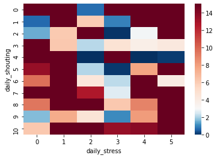

```python
norm=colors.TwoSlopeNorm(vmin=0, vcenter=15/5, vmax=15)
sns.heatmap(chi2_matrix_stress_shouting, norm=norm, cmap='RdBu_r');
```

```
Heatmap differences data observed - data expected
```

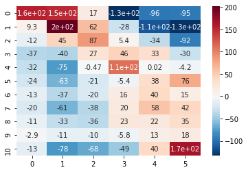

```python
# Differences observed-expected

df_diff = pd.DataFrame()
for col in df_concat_stress_shouting.columns.levels[0]:
    df_diff[col] = (df_concat_stress_shouting[(col,'Observed')] - df_concat_stress_shouting[(col,'Expected')])

norm=colors.TwoSlopeNorm(vmin=df_diff.min().min(), vcenter=0, vmax=df_diff.max().max())
print("\nHeatmap differences data observed - data expected")
sns.heatmap(df_diff, norm=norm, cmap="RdBu_r", annot=True);
```

Here the correlation is easily recognizable, being more cases of low stress for low shouting than expected from the proportions' distribution (positive observed-expected differences), and being more cases of high stress for high score of shouting than expected. One the other hand, there are negative differences (blues) for cross categories (low stress and high shouting, high stress and low shouting), indicating a lower number of people highly stressed among those not shouting so much, and also a lower number of people not so much stressed among those shouting. In general, **the more shouting, the more stress**

**2. t-test to check correlation**

```python
t_statistic = correlation_test(variable1, variable2)
p_value = (1 - t.cdf(t_statistic, n-2))*2
print("\n p-value: ", p_value)
```

```
Correlation coefficient r:  0.30926429602231414
Standar error of correlation coefficient:  0.008420995496599783

t statistic:  36.72538432625792

 p-value:  0.0
```

Again, residuals should be normally distributed, but all point to the alternative hypothesis: *stress* and *daily shouting* are positively correlated: the more shouting, the more stress.

## Attached:

Below it is shown a series of observations and notes for myself from ideas or solved questions arise during the present study. Take a look if you find it useful to a better understanding of approaches carried out in this project.

### 1. Performing sm.OLS we obtain different coefficients of that from `LinearRegression`:

```
import statsmodels.api as sm
lr = sm.OLS(y_train, X_train)
result = lr.fit()
result.summary2()
```

we see different coefficients respect to the ones from `LinearRegression`. Moreover, there are features with a few correlation with *daily_strees* and, however, a high *t* meaning a low probability of the correspondent coefficient to be 0 (for example, *social_network* has t=10,1 while the corr with *daily_stress* is 0.012720, so they are not correlated). What's happening? This is due to the fact that `sm.OLS` doesn't take the intercept by default, so in the adjustment by least squares, the function that minimize is:

$f = \sum (y_{i}^{pred}-y_{i})^2 = \sum (\beta_{1} x_{i} - y_{i})^2$, where $\beta_{1}, x_{i}$ can be vectors. The thing is that the intercept $\beta_{0}$ is not included.

This is $\sum (\beta_{0} + \beta_{1} x_{i} - y_{i})^2$, with $\beta_{0} = 0$. Thus, the resulting regression line passes through the origin (0,0) and the slope is different from 0. Adding `X = sm.add_constant(X)` before the `lr = sm.OLS(y, X)`, the variable `X` will include a column of ones, and the corresponding $\beta$ coefficient will be $\beta_{0}$ as it is multiplied by ones.

```
X_train_ones = sm.add_constant(X_train)
ols = sm.OLS(y_train, X_train_ones)
ols = ols.fit()
```

Doing this, we will obtain the intercept, and the result is the same as performing `LinearRegression` with our column of `X` (without the column of ones, as LinearRegression already takes into account the intercept in its default argument `intercept=True`)

### 2. Distribution of coefficients from random samples: $N(0,\sigma)$

```python
x = np.linspace(0,100,1000).reshape(-1,1)
y = np.random.rand(1000)*1000000

coeficientes = np.array([])
lin = LinearRegression()
for i in range(1000):
    y = np.random.rand(1000)*100
    lin.fit(x,y)
    coeficientes = np.hstack([coeficientes, lin.coef_])
```

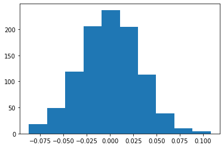

```python
plt.hist(coeficientes);
```

```python
from scipy.stats import normaltest
normaltest(coeficientes)
```

```
NormaltestResult(statistic=0.012647543546749278, pvalue=0.9936961811898626)
```

In random samples, the mean is the best model, the one which minimize the squared errors. Here we can see that the linear regression on random samples gives a coefficient of 0 with the most probability, following the coefficients a normal distribution: $coef \sim N(0,\sigma)$

### 3. Hypothesis tests about stress level and gender

We performed the analysis by stress levels, so giving a particular stress level, how many women and men answered. Let's perform some hypothesis test by gender. Giving the male answers, are they less stress than population in average? Are women more stressed than population in average?

H0: Men are as stressed as the average of the population

```python
df_concat_stress_gender
```

|  | 0 Expected | 0 Observed | 1 Expected | 1 Observed |
| --- | --- | --- | --- | --- |
| 0 | 339.887730 | 243 | 222.112270 | 319 |
| 1 | 1207.750529 | 1006 | 789.249471 | 991 |
| 2 | 1631.703018 | 1592 | 1066.296982 | 1106 |
| 3 | 2137.905919 | 2270 | 1397.094081 | 1265 |
| 4 | 1403.095257 | 1448 | 916.904743 | 872 |
| 5 | 993.657546 | 1155 | 649.342454 | 488 |

```python
real_df
```

[output not shown]

```python
real_df = df_concat_stress_gender[[(0,'Observed'),(1,'Observed')]]
expected_df = df_concat_stress_gender[[(0,'Expected'),(1,'Expected')]]
real_df.columns = real_df.columns.droplevel(1)
expected_df.columns = expected_df.columns.droplevel(1)

chi2 = sum((real_df[1] - expected_df[1])**2/expected_df[1])
chi2
```

[output not shown]

Rejected.

H0: Women are as stressed as the average of the population

```python
sum((real_df[0] - expected_df[0])**2/expected_df[0])
```

[output not shown]

Rejected.

### 4. Testing the significance of correlation coefficient

We saw that the categories of *daily stress* and *gender* are not independent. Now we would have to demonstrate that, besides this, there is a correlation, being women more stressed than men. The fact that there are dependent doesn't say anything about correlation.

About correlation, we obtained a value of `data.corr()['daily_stress']['gender'] = -0.12867`. Now we have to check if this is significantly different from zero to conclude there is not only a dependence but also a (negative) tendency. To obtain the significance, the test we have to perform is a t-test, were we have $H_{0}: \mu=0$, (where $\mu$ is the slope) and we estimate the standard deviation of the population slopes by the standard deviation of the slope we have obtained from our sample.

#### Sandard error of the slope in a linear regression:

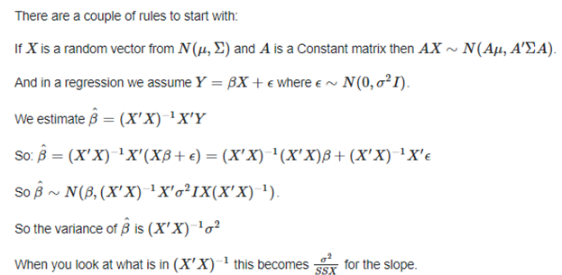

See that **the slope estimator variance come from the variance of the residuals, $\sigma$, considering residuals are normally distributed**. The meaning of the slope estimator variance is not that much the uncertainty of what is the value of the slope, the value that minimize the cost function, but it indicates the little differences in the value of the slope we had to use to predict each of the data. So we have a general $\beta_1$ unique, the one we use for all predictions, and the variance says that you might need to use another one slightly (or highly) different to obtain $y_i$ as $y_i = \beta_1·x_i$.

**The variance of $\beta_1$ should be interpreted as taking the residuals $\mathbf{\epsilon \sim N(0,\sigma)}$ into $\beta_1$ and leave only $\mathbf{y = \beta_1·x}$**, with $\beta_1$ having a variance, instead of $y = \beta_1 · x + \epsilon$

#### Calculation of t statistic

$\small \sigma^2 = MSE$, so:

$Std(\beta_1) = \large \frac{\sqrt{MSE}}{\sqrt{S_{xx}}} \hspace{.5cm}\normalsize [0]$

The calculated **value of the statistic t** is:

$t =\Large \frac{\beta_1 - 0}{Std(\beta_1)} \hspace{.5cm}\normalsize [1]$, where

$\beta_1 =\frac{\sum(x_i - \overline{x})(y_i - \overline{y})}{\sum(x_i - \overline{x})^2} \hspace{.5cm}\normalsize [2]$

is the expression for $\beta_1$ obtained by minimum squares and $Std(\beta_1)$ is given by [0]

We can also obtain an expression of t from the Pearson correlation coefficient, *r*. We need the relation between $\beta_1$ and r:

$\beta_1 = r·\frac{S_{yy}}{S_{xx}} \hspace{.5cm}\normalsize [3]$

which is deducted from [2] and the expression for the Pearson correlation coefficient, r: $r=\frac{S_{xy}}{S_{xx}·S_{yy}}$. Taking [3] into account and similarly to the demonstration above of the standard error of the slope in a linear regression, we obtain that $std(r) = std(\beta_1)·\frac{\sqrt{S_{yy}}}{\sqrt{S_{xx}}} = ... = \sqrt{\frac{1-r^2}{N-2}} \hspace{.5cm}\normalsize [4]$ (were we consider $r^2 = 1 - \frac{SSE}{SST}$), and finally:

$\large t = \frac{r - 0}{std(r)} = \frac{r}{\sqrt{\frac{1-r^2}{N-2}}} = ... = \frac{r·\sqrt{N-2}}{\sqrt{1-r^2}} \hspace{.5cm}\normalsize [5]$

#### Comparision with the values returned by `sm.OLS(y, X).fit().summary2()`

Let's see that the values for t obtaind by hand from [1] or from [4], as well as the value for $Std(\beta_1)$ from [0], are those shown authomatically with the method `summary2()` of the object `sm.OLS`, the linear regressor of OLS of statsmodels.api:

```python
# t with Eq.[5]

r = data.corr(method='pearson')['daily_stress']['gender']
N = data.shape[0]
std_r = np.sqrt((1-r**2)/(N-2)) #Equation [4]
t = (r-0)/std_r #Equation [5]
print(t)
```

```python
# t with Eq.[1]

t = result.params['gender'] / std_b1 #Equation [1]
print(t)
```

```python
import statsmodels.api as sm
y = data['daily_stress']
X = sm.add_constant(data['gender'])
lr = sm.OLS(y, X)
result = lr.fit()
```

```python
rmse = np.sqrt(mean_squared_error(y, result.predict(sm.add_constant(X['gender']))))
Sxx = ((X['gender'] - X['gender'].mean())**2).sum()

std_b1 = rmse/np.sqrt(Sxx) #Equation [0]
print(std_b1)
```

```python
result.summary2()
```

[output not shown]

#### Note and discussion: Residuals are not normally distributed

The expression for the slope estimator's variance come from assuming normally distributed residuals. However, this is not our case (I tried transforming the data, but I can't obtain normally distributed residuals in any case), so we should be prudent with the conclusions we have reached here. However, there are other studies affirming that women suffer more stress than men, as well as studies about the so-called "financial stress" that relate stress with low income. Besides, in our study we easily appreciate the lower number of observed cases of women with low stress levels, compared to expected cases, and the higher number of women with high stress levels, and since the dependency of the categories is guaranteed by the $\chi^2$ test of independency (not affected by the distribution of residuals, as this test has nothing to do with descriptive tendency models and just deal with unordered categories), it is very likely a real correlation.

### 5. Pearson correlation coefficient VS Linear regression coeficient

Pearson correlation coefficient (r) is an indirect measure of the t-statistic, which determines whether the linear regression cofficient ($\beta_1$) is 0 (t~0) or not (|t|>>0). The relation of these two is $\frac{r·\sqrt{N-2}}{\sqrt{1-r^2}}$, and as we can appreciate, $r \rightarrow 0, t \rightarrow 0$ and $|r| \rightarrow 1, |t| >>> 0$. The magnitude of r tells how well data fit a straight line, and the higher r, the lower $\beta_1$ will vary from its estimated value ($\Delta \beta_1 \sim 0$) and thus the less likely it is to be 0 (strictly, the less likely is that, if it were 0 in reality, we had obtain that so well aligned and low-varianced data).

**Coefficients VS Correlations (Pearson)**

```python
df_coef = pd.DataFrame(list(zip(X.columns, OLSresults.params[1:])), columns=['Feature', 'Coefficient LR'])
df_coef['Pearson Correlation r'] = data.corr()['daily_stress'].drop('daily_stress').values
df_coef.sort_values(by='Coefficient LR')
```

|  | Feature | Coefficient LR | Pearson Correlation r |
| --- | --- | --- | --- |
| 19 | gender | -0.331477 | -0.128677 |
| 14 | sufficient_income | -0.256305 | -0.144872 |
| 11 | sleep_hours | -0.095864 | -0.152862 |
| 17 | daily_meditation | -0.048766 | -0.213672 |
| 16 | time_for_passion | -0.032759 | -0.161858 |
| 8 | flow | -0.029573 | -0.142187 |
| 2 | core_circle | -0.023396 | -0.115973 |
| 7 | todo_completed | -0.023260 | -0.166975 |
| 0 | fruits_veggies | -0.019387 | -0.095132 |
| 5 | achievement | -0.016670 | -0.120786 |
| 10 | live_vision | -0.015525 | -0.135016 |
| 1 | places_visited | -0.012374 | -0.131707 |
| 6 | donation | -0.000887 | -0.038291 |
| 9 | daily_steps | 0.004181 | -0.057925 |
| 3 | supporting_others | 0.019178 | -0.035373 |
| 18 | age | 0.020990 | -0.020649 |
| 15 | personal_awards | 0.022434 | -0.044362 |
| 4 | social_network | 0.023383 | 0.012720 |
| 12 | lost_vacation | 0.048679 | 0.192353 |
| 13 | daily_shouting | 0.125297 | 0.309264 |

Linear Regression coefficients does not follow the same ascending/descending order as correlation Pearson coefficients (r). As we mencioned above, correlation Pearson coefficients tell how well the linear model fit to data, but not how much the variable influence on stress. What tell us about what features influence the most on stress is the magnitude of linear regression coefficient.

[Portafolio](https://carlespan.github.io/#portafolio)